# Permutation-based genetic association test

Brian Kissmer

2024-10-22

## **Purpose of this assignment**

This assignment allows you to apply the material we covered last week on bootstrapping and permutation to a real data set.

## **Task**

*Timema cristinae* stick insects exist as two color pattern morphotypes, one that is all green and one that is green with a white stripe (Fig. 1). Each morphotype is more cryptic on one of two host plants fed on by this species. DNA sequence data indicate that this species harbors a polymorphic inversion on chromosome 8 (the inversion is about 10 million base pairs in length). The inversion might or might not be responsible for the color pattern polymorphism (i.e., the existence of the two ecotypes). The data below give the number of stick insects of each morphotype with each inversion genotype (homozygous original, heterozygous, or homozygous inversion). Use a permutation test to evaluate the null hypothesis that inversion allele is not associated with color pattern. `rep` might be useful for entering the data in R. Consider using the difference in the inversion allele frequency between morphs as your test statistic.

| Genotype | Striped | Unstriped |
| --- | --- | --- |
| Homozygous original | 5 | 85 |
| Heterozygous | 65 | 13 |
| Homozygous inversion | 50 | 0 |

Post your code and results on the “Permutation testing” discussion.

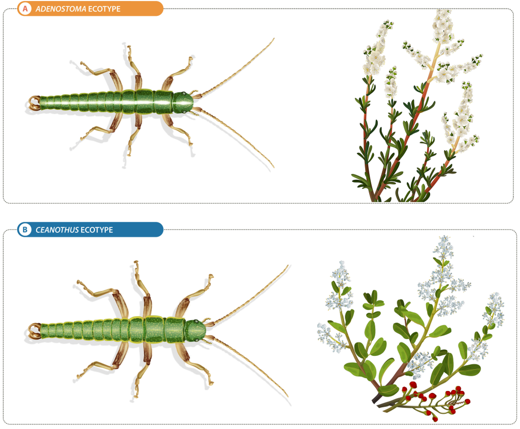

Figure 1: *T. cristinae* morphotypes and host plants